# gtsummary: Making Summary Tables for Publications

```r
library(tidyverse)
library(gtsummary)
library(gt)
library(palmerpenguins)
library(flextable)
```

Lets peek at the documentation for `gtsummary`

https://www.danieldsjoberg.com/gtsummary/

It is very common (especially in biomedical literature) for the first table of the paper to summarize attributes of the participants in the study. This is a first look at whether the study could have some built-in demographic bias.

```r
tbl_summary(trial, by = trt)
```

| **Characteristic** | **Drug A**, N = 98<sup>1</sup> | **Drug B**, N = 102<sup>1</sup> |
| --- | --- | --- |
| Age | 46 (37, 59) | 48 (39, 56) |
| Unknown | 7 | 4 |
| Marker Level (ng/mL) | 0.84 (0.24, 1.57) | 0.52 (0.19, 1.20) |
| Unknown | 6 | 4 |
| T Stage |  |  |
| T1 | 28 (29%) | 25 (25%) |
| T2 | 25 (26%) | 29 (28%) |
| T3 | 22 (22%) | 21 (21%) |
| T4 | 23 (23%) | 27 (26%) |
| Grade |  |  |
| I | 35 (36%) | 33 (32%) |
| II | 32 (33%) | 36 (35%) |
| III | 31 (32%) | 33 (32%) |
| Tumor Response | 28 (29%) | 33 (34%) |
| Unknown | 3 | 4 |
| Patient Died | 52 (53%) | 60 (59%) |
| Months to Death/Censor | 23.5 (17.4, 24.0) | 21.2 (14.6, 24.0) |

<sup>1</sup> Median (IQR); n (%)

```r
  #uses all variables in a given table, so table should be relatively clean before summarizing
```

**Example 1 t-test: Summarizing/Comparing Two Groups**

```r
draco_ecomorph <- read_csv("../data/draco_ecomorph.csv")
##..means look up one level for the 'data'folder
```

```r
# summarize the data; includes all species, so not that helpful yet
table1 <-
  draco_ecomorph %>%
  tbl_summary(by=sex,
              missing = "no", #gets rid of pesky NAs
              include = c(snout_vent_length_mm, tail_length_mm, fore_limb_length_mm))

table1
```

| **Characteristic** | **female**, N = 66<sup>1</sup> | **male**, N = 183<sup>1</sup> |
| --- | --- | --- |
| snout_vent_length_mm | 76 (72, 84) | 75 (70, 79) |
| tail_length_mm | 121 (111, 138) | 116 (105, 140) |
| fore_limb_length_mm | 30.7 (27.7, 36.8) | 30.4 (26.3, 36.9) |

<sup>1</sup> Median (IQR)

Note that the default here is median and IQR for summary statistics; not what we might want. You can change the defaults behavior by setting a theme, or define manually (I prefer for complete control). Its more customary to use mean and SD (or SE) to summarize groups since we are most likely going to use parametric statistics for comparison.

```r
theme_gtsummary_mean_sd(set_theme = TRUE)
#Sets default summary statistics to mean and standard deviation in tbl_summary()
#Sets default continuous tests in add_p() to t-test and ANOVA
```

```r
#gtsummary works best with datasets without NA values, otherwise it attempts to report # of NAs (annoying)

table_Draco1 <- draco_ecomorph %>%
  filter(species =="bimaculatus") %>%
  select(sex, snout_vent_length_mm, tail_length_mm, fore_limb_length_mm, fore_toe_length_mm, perch_height_cm) %>%
  #retain specific variables used in summaries rather than using all
  tbl_summary(
    by = sex,
    missing = "no",
    # remove missing values (NAs). "ifany" will include a missing values row in table.
    digits = all_continuous() ~ 1,
    #number of displayed digits for continuous variables
    label = list(
      snout_vent_length_mm ~ "SVL (mm)",
      tail_length_mm ~ "Tail Length (mm)",
      fore_limb_length_mm ~ "Forelimb Length (mm)",
      fore_toe_length_mm ~ "Foretoe Length (mm)",
      perch_height_cm ~ "Perch Height (cm)"
    ),
    statistic = list(all_continuous() ~ "{mean} ({sd})", #can use any character for parentheses
                     all_categorical() ~ "{n}")
  ) %>% #count obs. for categorical variables
  add_p(pvalue_fun = ~ style_pvalue(.x, digits = 2)) %>% #number of digits displayed for p-values
  modify_caption("Table 1. *Draco bimaculatus* Morphological Characteristics") %>%
  modify_header(
    update = list(
      label ~ '',
      stat_1 ~ '**Female**', #is markdown **bold** formatting
      stat_2 ~ '**Male**',
      p.value ~ '**P-value**')
  )

#show_header_names(table_Draco)
#lets you preview code for changing header names and formatting

table_Draco1
```

Table 1. *Draco bimaculatus* Morphological Characteristics

|  | **Female**<sup>1</sup> | **Male**<sup>1</sup> | **P-value**<sup>2</sup> |
| --- | --- | --- | --- |
| SVL (mm) | 65.4 (7.4) | 71.1 (7.6) | 0.039 |
| Tail Length (mm) | 112.9 (13.4) | 114.6 (13.4) | 0.71 |
| Forelimb Length (mm) | 29.1 (3.4) | 29.3 (3.9) | 0.82 |
| Foretoe Length (mm) | 9.4 (1.2) | 10.3 (1.3) | 0.040 |
| Perch Height (cm) | 290.1 (136.2) | 403.4 (170.7) | 0.032 |

<sup>1</sup> Mean (SD)  
<sup>2</sup> Welch Two Sample t-test

**Example 2 ANOVA Lizards: Summarizing/Comparing Three Groups**

```r
#this function works best with datasets without NA values

table_Draco2 <- draco_ecomorph %>%
  select(species, sex, snout_vent_length_mm, perch_height_cm) %>% #retain variables used in summaries
  filter(species %in% c("bimaculatus", "cornutus", "melanopogon")) %>%
  tbl_summary(
    by = species,
    #every species gets its own column and summary stats
    missing = "no",
    # remove missing values (NAs). "ifany" will include a missing values row in table.
    digits = all_continuous() ~ 1,
    #number of displayed digits for continuous variables
    label = list(
      snout_vent_length_mm ~ "SVL (mm)",
      #change column labels in table
      perch_height_cm ~ "Perch Height (cm)",
      sex ~ "Sex"
    ),
    statistic = list(all_continuous() ~ "{mean} ({sd})", #can use any character for parentheses
                     all_categorical() ~ "{n}")
  ) %>% #count obs. for categorical variables
  #add_p(snout_vent_length_mm ~ "aov") %>% CANT FIGURE OUT HOW TO FORCE ANOVA
  add_p(pvalue_fun = ~ style_pvalue(.x, digits = 2)) %>% #number of digits displayed for p-values
  modify_caption("Table 2. Lizard and Habitat Characteristics") %>%
  #modify_header(update = all_stat_cols() ~ "**{level}**") %>%  #headers to only contain species name
  #modify_footnote(all_stat_cols() ~ NA) %>% #squashes superscripts for the groups
  modify_footnote(everything() ~ NA) %>%
  modify_header(
    update = list(
      label ~ '',
      stat_1 ~ '**D. bimaculatus**',
      stat_2 ~ '**D. cornutus**',
      stat_3 ~ '**D. melanopogon**',
      p.value ~ '**P-value**'
    )
  )

#show_header_names(table_Draco1)
#lets you preview code for changing header names and formatting

table_Draco2
```

Table 2. Lizard and Habitat Characteristics

|  | **D. bimaculatus** | **D. cornutus** | **D. melanopogon** | **P-value** |
| --- | --- | --- | --- | --- |
| Sex |  |  |  | 0.62 |
| female | 11 | 17 | 11 |  |
| male | 41 | 41 | 33 |  |
| SVL (mm) | 69.9 (7.9) | 76.4 (4.6) | 77.2 (4.6) | <0.001 |
| Perch Height (cm) | 379.4 (169.4) | 504.0 (185.9) | 335.1 (166.8) | <0.001 |

```r
table_Draco2 %>%
  as_flex_table() %>%
  flextable::save_as_docx(path = "../figs/table_Draco2.docx")
```

```r
#table_Draco2 %>%
  #as_gt() %>%   # convert to gt table for additional formatting options and saving
  #gt::gtsave(filename = "draco_ecomorph_table.pdf") #save file
```

If data have missing values that make groups unbalanced, might have to make more than one table and combine them. Parts of a gt table: https://gt.rstudio.com/articles/intro-creating-gt-tables.html

Advanced Customization

It’s natural a `gtsummary` user would want to customize the aesthetics of the table with one or more of the many `gt` functions available.

Every function in `gt` is available to use with a {gtsummary} object.

1. Create a `gtsummary` table.
2. Convert the table to a `gt` object with the `as_gt()` function.
3. Continue formatting as a `gt` table with any `gt` function.

**Example 3 ANOVA Penguins**

```r
table_penguins <- penguins %>%
  select(species, sex, bill_length_mm, bill_depth_mm, flipper_length_mm, body_mass_g) %>% #retain variables used in summaries
  tbl_summary(by = species,
              missing = "no", # remove missing values (NAs). "ifany" will include a missing values row in table.
              digits = all_continuous() ~ 1, #number of displayed digits for continuous variables
              label = list(bill_length_mm ~ "Bill Length (mm)", #change column labels in table
                           bill_depth_mm ~ "Bill Depth (mm)",
                           flipper_length_mm ~ "Flipper Length (mm)",
                           body_mass_g ~ "Body Mass (g)",
                           sex ~ "Sex"),
              statistic = list(all_continuous() ~ "{mean} ({sd})", #can use any character for parentheses
                               all_categorical() ~ "{n}")) %>% #count obs. for categorical variables
  add_p(pvalue_fun = ~style_pvalue(.x, digits = 2)) %>% #number of digits displayed for p-values
  modify_caption("Table 3. Palmer Penguin Morphometrics") %>%
  modify_header(update = all_stat_cols() ~ "**{level}**") %>% #headers to only contain species name
  as_gt() %>% #have to convert to gt object for some types of formatting
  gt::tab_options(heading.align = "left")
#table caption appears left aligned AFTER it is knit to html.

table_penguins
```

Table 3. Palmer Penguin Morphometrics

| **Characteristic** | **Adelie**<sup>1</sup> | **Chinstrap**<sup>1</sup> | **Gentoo**<sup>1</sup> | **p-value**<sup>2</sup> |
| --- | --- | --- | --- | --- |
| Sex |  |  |  | 0.98 |
| female | 73 | 34 | 58 |  |
| male | 73 | 34 | 61 |  |
| Bill Length (mm) | 38.8 (2.7) | 48.8 (3.3) | 47.5 (3.1) | <0.001 |
| Bill Depth (mm) | 18.3 (1.2) | 18.4 (1.1) | 15.0 (1.0) | <0.001 |
| Flipper Length (mm) | 190.0 (6.5) | 195.8 (7.1) | 217.2 (6.5) | <0.001 |
| Body Mass (g) | 3,700.7 (458.6) | 3,733.1 (384.3) | 5,076.0 (504.1) | <0.001 |

<sup>1</sup> n; Mean (SD)  
<sup>2</sup> Pearson’s Chi-squared test; One-way ANOVA

**Example 4 ANCOVA Lizards**

```r
draco_bimaculatus <- draco_ecomorph %>%
  filter(species == "bimaculatus") #get one species to work with
```

```r
#ANCOVA measurements adjusted for SVL covariate

ex4 <- draco_bimaculatus%>%
  select(tail_length_mm, snout_vent_length_mm, fore_limb_length_mm, hind_limb_length_mm, sex)%>%
  tbl_summary(by=sex,
              #statistic=list(all_continuous()~"{mean}({sd})"),
              #missing="no",
              digits = all_continuous() ~ 1,
              include=c(tail_length_mm, fore_limb_length_mm, hind_limb_length_mm),
              )%>%
  add_difference(adj.vars=c(snout_vent_length_mm)) #this one line turns it from an ANOVA to an ANCOVA table
  #add_p(pvalue_fun = ~ style_pvalue(.x, digits = 2))   #cannot get to work; throws error

ex4
```

| **Characteristic** | **female**, N = 11<sup>1</sup> | **male**, N = 41<sup>1</sup> | **Adjusted Difference**<sup>2</sup> | **95% CI**<sup>2,3</sup> | **p-value**<sup>2</sup> |
| --- | --- | --- | --- | --- | --- |
| tail_length_mm | 112.9 (13.4) | 114.6 (13.4) | 0.17 | -9.3, 9.7 | >0.9 |
| fore_limb_length_mm | 29.1 (3.4) | 29.3 (3.9) | -0.78 | -3.5, 1.9 | 0.6 |
| hind_limb_length_mm | 34.3 (5.5) | 34.6 (4.9) | -1.3 | -4.8, 2.2 | 0.5 |

<sup>1</sup> Mean (SD)  
<sup>2</sup> ANCOVA  
<sup>3</sup> CI = Confidence Interval

```r
ex4 %>%
  as_flex_table() %>%
  flextable::save_as_docx(path = "../figs/ex4_flextable.docx")
```

```r
#if you include SVL as a variable in the list to be analyzed by gtsummary, it does a t-test on SVL, not ANCOVA
t.test(snout_vent_length_mm~sex, data=draco_bimaculatus)
```

```
##
##  Welch Two Sample t-test
##
## data:  snout_vent_length_mm by sex
## t = -2.2456, df = 16.122, p-value = 0.03909
## alternative hypothesis: true difference in means between group female and group male is not equal to 0
## 95 percent confidence interval:
##  -11.0763763  -0.3222933
## sample estimates:
## mean in group female   mean in group male
##             65.41091             71.11024
```

SVL variable (snout_vent_length_mm) is excluded from table above; if you wanted to include it, you would need to explain the table in more depth because it has both a single t-test for SVL (raw means) and a bunch on ANCOVAs for the other variables (presenting marginal means).

```r
model_1 <- lm(tail_length_mm ~ snout_vent_length_mm + sex, data=draco_bimaculatus)
#notice this is a parallel slopes model (How can you tell?)
summary(model_1)
```

```
##
## Call:
## lm(formula = tail_length_mm ~ snout_vent_length_mm + sex, data = draco_bimaculatus)
##
## Residuals:
##     Min      1Q  Median      3Q     Max
## -37.265  -8.599  -1.929   8.571  34.402
##
## Coefficients:
##                      Estimate Std. Error t value Pr(>|t|)
## (Intercept)           91.1163    16.7151   5.451 1.62e-06 ***
## snout_vent_length_mm   0.3332     0.2481   1.343    0.185
## sexmale               -0.1738     4.7351  -0.037    0.971
## ---
## Signif. codes:  0 '***' 0.001 '**' 0.01 '*' 0.05 '.' 0.1 ' ' 1
##
## Residual standard error: 13.31 on 49 degrees of freedom
## Multiple R-squared:  0.03826,    Adjusted R-squared:  -0.000991
## F-statistic: 0.9748 on 2 and 49 DF,  p-value: 0.3845
```

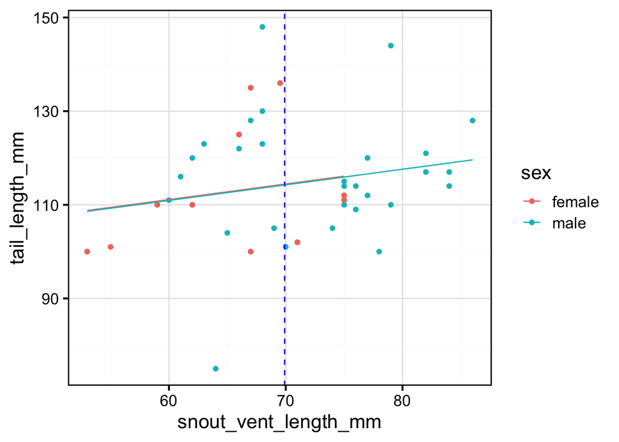

```r
#make ANCOVA from a fit model; one of many ways to do this.
model_1_fortified <- fortify(model_1)
ggplot(model_1) +
  geom_point(aes(x = snout_vent_length_mm, y = tail_length_mm, color = sex)) +
  geom_line(aes(x = snout_vent_length_mm, y = .fitted, color = sex)) +
  geom_vline(xintercept=mean(draco_bimaculatus$snout_vent_length_mm), linetype='dashed', color='blue', size=0.5) +
  theme_cmg() #this was my theme defined in a script
```

For tail length, the adjusted difference and P-value matches `gtsummary` output. There is not a noticeable difference in tail length between the sexes at the grand mean.

```r
summary(model_1)$coefficients["sexmale","Estimate"] #adjusted difference between marginal means
```

```
## [1] -0.173778
```

```r
summary(model_1)$coefficients["sexmale","Pr(>|t|)"] #p-value comparing adjusted means
```

```
## [1] 0.9708731
```

If more formatting is required, likely have to convert `gtsummary` object to a `gt` object and modify with `gt` package.

Other worked examples:

https://cran.r-project.org/web/packages/gtsummary/vignettes/gallery.html

https://www.pipinghotdata.com/posts/2021-07-14-polished-summary-tables-in-r-with-gtsummary/